# AutoML: Boro Yield Prediction

Zia Ahmed, Unversity at Buffalo

```r
setwd(gsub(pattern = '/scripts', replacement = '', x = getwd()))
```

# AutoML: Automatic Machine Learning

In recent years, the demand for machine learning experts has outpaced the supply, despite the surge of people entering the field. To address this gap, there have been big strides in the development of user-friendly machine learning software that can be used by non-experts. The first steps toward simplifying machine learning involved developing simple, unified interfaces to a variety of machine learning algorithms (e.g. H2O).

Although H2O has made it easy for non-experts to experiment with machine learning, there is still a fair bit of knowledge and background in data science that is required to produce high-performing machine learning models. Deep Neural Networks in particular are notoriously difficult for a non-expert to tune properly. In order for machine learning software to truly be accessible to non-experts, we have designed an easy-to-use interface which automates the process of training a large selection of candidate models. H2O’s AutoML can also be a helpful tool for the advanced user, by providing a simple wrapper function that performs a large number of modeling-related tasks that would typically require many lines of code, and by freeing up their time to focus on other aspects of the data science pipeline tasks such as data-preprocessing, feature engineering and model deployment.

H2O’s AutoML can be used for automating the machine learning workflow, which includes automatic training and tuning of many models within a user-specified time-limit. Stacked Ensembles – one based on all previously trained models, another one on the best model of each family – will be automatically trained on collections of individual models to produce highly predictive ensemble models which, in most cases, will be the top performing models in the AutoML Leaderboard.

H2O offers a number of model explainability methods that apply to AutoML objects (groups of models), as well as individual models (e.g. leader model). Explanations can be generated automatically with a single function call, providing a simple interface to exploring and explaining the AutoML models.

#### Set working directory

```r
#setwd("/mnt/d/Dropbox/CIMMYT_UB/NEW_ANALYSIS/ANALYSIS/BORO/ALL_DATA")
setwd("/home/zia207/Dropbox/CIMMYT_UB/NEW_ANALYSIS/ANALYSIS/Yield/BORO/AutoML_Boro_Yield")
```

#### Load Pcakages

```r
library(plyr)
library(tidyverse)
library(dplyr)
library(classInt)
library(data.table)
library(magrittr)
library(DT)
#library(kableExtra)
require(reshape2)
#library(pROC)
library(pdp)       # for partial dependence plots (and ICE curves)
library(vip)       # for variable importance plots
library(iml)       # for general IML-related functions
library(DALEX)     # for general IML-related functions
library(lime)      # for local interpretable model-agnostic explanations
library(breakDown)
library(iBreakDown)
#library(localICE)
#library(tidyquant) #for better ggplot theme
library(purrrlyr)
```

### Load data

```r
mf<-read.csv("boro_data_all.csv", header = T)
train.mf<-read.csv("train_data.csv", header = T)
test.mf<-read.csv("test_data.csv", header = T)
```

```r
names(mf)
```

```
##  [1] "ID"                 "Index"              "Crop"
##  [4] "Seasons"            "Seasons_types"      "UNION_ID"
##  [7] "x"                  "y"                  "LONG"
## [10] "LAT"                "DIVISION"           "DISTRICT"
## [13] "UPAZILA"            "UNION"              "Total_GWP"
## [16] "Emission_Intensity" "YIELD"              "GD"
## [19] "N_rate"             "P_rate"             "K_rate"
## [22] "BD"                 "pH"                 "SOC"
## [25] "N"                  "P"                  "K"
## [28] "S"                  "Zn"                 "DEM"
## [31] "NDVI_305_2014"      "NDVI_321_2014"      "NDVI_337_2014"
## [34] "NDVI_353_2014"      "NDVI_001_2105"      "NDVI_017_2015"
## [37] "NDVI_033_2015"      "NDVI_049_2015"      "NDVI_065_2015"
## [40] "NDVI_081_2015"      "NDVI_097_2015"      "NDVI_113_2015"
## [43] "t2m_305_2014"       "t2m_321_2014"       "t2m_337_2014"
## [46] "t2m_353_2014"       "t2m_017_2015"       "t2m_033_2015"
## [49] "t2m_049_2015"       "t2m_065_2015"       "t2m_081_2015"
## [52] "t2m_097_2015"       "t2m_113_2015"       "tp_305_2014"
## [55] "tp_321_2014"        "tp_337_2014"        "tp_353_2014"
## [58] "tp_017_2015"        "tp_033_2015"        "tp_049_2015"
## [61] "tp_065_2015"        "tp_081_2015"        "tp_097_2015"
## [64] "tp_113_2015"        "Crop_Types"         "LT_Class"
## [67] "General_Soil_Type"  "DRC_Class"          "TZONE_Class"
## [70] "Soil_texture"       "Water_regime"       "Manure"
## [73] "OLD_DRC_CLASS"      "LT"                 "STYPE"
## [76] "exTZONE"            "DRC"                "OLD_DRC"
## [79] "Urea_Amount"        "TSP_Amount"         "DAP_Amount"
## [82] "MP_Amount"
```

### Create data frame-function

```r
FeatureData <- function(data) {
  features <- c(
                "GD",              # 1
                "N_rate",          # 2
                "P_rate",          # 3
                "K_rate",          # 4

                "pH",              # 5
                "SOC",             # 6
                "N",               # 7
                "P",               # 8
                "K",               # 9
                "S",               # 10
                "Zn",              # 11

                "DEM",             # 12

                "NDVI_305_2014",   # 13
                "NDVI_321_2014",   # 14
                "NDVI_337_2014",   # 15
                "NDVI_353_2014",   # 16
                "NDVI_001_2105",   # 17
                "NDVI_017_2015",   # 18
                "NDVI_033_2015",   # 19
                "NDVI_049_2015",   # 20
                "NDVI_065_2015",   # 21
                "NDVI_081_2015",   # 22
                "NDVI_097_2015",   # 23
                "NDVI_113_2015",   # 24

                "t2m_305_2014",    # 25
                "t2m_321_2014",    # 26
                "t2m_337_2014",    # 27
                "t2m_353_2014",    # 28
                "t2m_017_2015",    # 29
                "t2m_033_2015",    # 30
                "t2m_049_2015",    # 31
                "t2m_065_2015",    # 32
                "t2m_081_2015",    # 33
                "t2m_097_2015",    # 34
                "t2m_113_2015",    # 35


                "tp_305_2014",     # 36
                "tp_321_2014",     # 37
                "tp_337_2014",     # 38
                "tp_353_2014",     # 39
                "tp_017_2015",     # 40
                "tp_033_2015",     # 41
                "tp_049_2015",     # 42
                "tp_065_2015",     # 43
                "tp_081_2015",     # 44
                "tp_097_2015",     # 45
                "tp_113_2015",     # 46

                "Crop_Types",        # 47
                "LT_Class",          # 48
                "General_Soil_Type", # 49
                "DRC_Class",         # 50
                "TZONE_Class",       # 51
                "Soil_texture",      # 52
                "Water_regime",      # 53
                "Manure",            # 54

                "YIELD")
                fea <- data[,features]
                fea[, 1:46] = scale(fea[, 1:46])            # scale predictors
                fea[,47:54]= dmap(fea[,47:54], as.factor)   # convert to factors
                return(fea)
                 }
```

```r
df<-FeatureData(mf)
train.df<-FeatureData(train.mf)
test.df<-FeatureData(test.mf)
```

```r
write.csv(train.df, "train_data_scaled.csv", row.names = T)
write.csv(test.df, "test_data_scaled.csv", row.names = T)
```

### Connect to H2o server

```r
library(h2o)
h2o.init(nthreads = -1,max_mem_size ="48g",enable_assertions = FALSE)
```

```r
h2o.no_progress() # disable progress bar for RMarkdown
h2o.removeAll()   # Optional: remove anything from previous session
```

### Create h2o dataframe

```r
h_df<-  as.h2o(df)
h_train<-  as.h2o(train.df)
h_test<- as.h2o(test.df)
```

### Define response and predictors

```r
y <- "YIELD"
x <- setdiff(names(h_train), y)
```

### Create data frame for Explianers

### All Data

```r
x_all <- as.data.frame(h_df) %>% dplyr::select(-YIELD)
y_all<- as.data.frame(h_df) %>% pull(YIELD)
```

### Training

```r
x_train <- as.data.frame(h_train) %>% dplyr::select(-YIELD)
y_train <- as.data.frame(h_train) %>% pull(YIELD)
```

### Test

```r
x_test <- as.data.frame(h_test) %>% dplyr::select(-YIELD)
y_test <- as.data.frame(h_test) %>% pull(YIELD)
```

# Auto ML

```r
train.aml <- h2o.automl(
                  x= x,
                  y = y,
                  training_frame = h_train,
                  nfolds=10,
                  keep_cross_validation_predictions = TRUE,
                  stopping_metric = "RMSE",
                  stopping_tolerance = 0.001,
                  stopping_rounds = 3,
                  max_runtime_secs_per_model = 0,
                  seed = 42,
                  #max_models = 20,
                  project_name = "AutoML_trainings")
```

## Leaderboard

Next, we will view the AutoML Leaderboard. A default performance metric for each machine learning task (binary classification, multiclass classification, regression) is specified internally and the leaderboard will be sorted by that metric. In the case of regression, the default ranking metric is mean residual deviance. In the future, the user will be able to specify any of the H2O metrics so that different metrics can be used to generate rankings on the leaderboard.

```r
lb <- h2o.get_leaderboard(object = train.aml, extra_columns = "ALL")
datatable(as.data.frame(lb),
          rownames = FALSE, options = list(pageLength = 10, scrollX = TRUE, round)) %>%
  formatRound(columns = -1, digits = 4)
write.csv(as.data.frame(lb), "Model_Stat_AutoML.csv", row.names = F)
```

### The best Model

```r
best_ML<- h2o.get_best_model(train.aml, criterion = "RMSE" )
best_ML
```

```
## Model Details:
## ==============
##
## H2ORegressionModel: stackedensemble
## Model ID:  StackedEnsemble_AllModels_3_AutoML_1_20211104_123317
## Number of Base Models: 188
##
## Base Models (count by algorithm type):
##
## deeplearning          drf          gbm          glm      xgboost
##            6            2          141            1           38
##
## Metalearner:
##
## Metalearner algorithm: glm
## Metalearner cross-validation fold assignment:
##   Fold assignment scheme: AUTO
##   Number of folds: 10
##   Fold column: NULL
## Metalearner hyperparameters:
##
##
## H2ORegressionMetrics: stackedensemble
## ** Reported on training data. **
##
## MSE:  245403.5
## RMSE:  495.3822
## MAE:  351.1353
## RMSLE:  0.3328396
## Mean Residual Deviance :  245403.5
##
##
##
## H2ORegressionMetrics: stackedensemble
## ** Reported on cross-validation data. **
## ** 10-fold cross-validation on training data (Metrics computed for combined holdout predictions) **
##
## MSE:  1237460
## RMSE:  1112.412
## MAE:  772.5589
## RMSLE:  0.4315555
## Mean Residual Deviance :  1237460
```

### Save Model

```r
model_path <- h2o.saveModel(object = best_ML, path = getwd(), force = TRUE)
print(model_path)
```

```
## [1] "/home/zia207/Dropbox/CIMMYT_UB/NEW_ANALYSIS/ANALYSIS/Yield/BORO/AutoML_Boro_Yield/StackedEnsemble_AllModels_3_AutoML_1_20211104_123317"
```

### The best Stack Ensemble of all models

```r
model_ids<-as.data.frame(lb)$model_id
stack_all<-h2o.getModel(grep("StackedEnsemble_AllModels", model_ids, value=TRUE)[1])
stack_all_meta<-stack_all@model$metalearner_model
stack_all_meta
```

```
## Model Details:
## ==============
##
## H2ORegressionModel: glm
## Model ID:  metalearner_AUTO_StackedEnsemble_AllModels_3_AutoML_1_20211104_123317
## GLM Model: summary
##     family     link                              regularization
## 1 gaussian identity Elastic Net (alpha = 0.5, lambda = 2823.3 )
##   number_of_predictors_total number_of_active_predictors number_of_iterations
## 1                        188                           9                    1
##                                                           training_frame
## 1 levelone_training_StackedEnsemble_AllModels_3_AutoML_1_20211104_123317
##
## Coefficients: glm coefficients
##                                          names coefficients
## 1                                    Intercept     6.693112
## 2               DRF_1_AutoML_1_20211104_123317     0.485496
## 3               XRT_1_AutoML_1_20211104_123317     0.134947
## 4 GBM_grid_1_AutoML_1_20211104_123317_model_34     0.239958
## 5 GBM_grid_1_AutoML_1_20211104_123317_model_80     0.035401
##   standardized_coefficients
## 1               5530.141159
## 2                557.721230
## 3                151.498683
## 4                288.446236
## 5                 42.713189
##
## ---
##                                                    names coefficients
## 184              DeepLearning_1_AutoML_1_20211104_123317     0.000000
## 185 DeepLearning_grid_1_AutoML_1_20211104_123317_model_3     0.000000
## 186 DeepLearning_grid_1_AutoML_1_20211104_123317_model_4     0.000000
## 187 DeepLearning_grid_1_AutoML_1_20211104_123317_model_5     0.000000
## 188        GBM_grid_1_AutoML_1_20211104_123317_model_136     0.000000
## 189                       GLM_1_AutoML_1_20211104_123317     0.000000
##     standardized_coefficients
## 184                  0.000000
## 185                  0.000000
## 186                  0.000000
## 187                  0.000000
```

[output cut: 59 more lines]

```
## mse                       1250012.800000    1116447.800000    1269721.600000
## null_deviance          1057140740.000000 1255874820.000000 1067668610.000000
## r2                              0.480630          0.551053          0.479426
## residual_deviance       548755580.000000  563806140.000000  554868350.000000
## rmse                         1118.039700       1056.621000       1126.819200
## rmsle                           0.264675          0.393043          0.278975
##                               cv_8_valid        cv_9_valid       cv_10_valid
## mae                           728.434000        778.798650        800.873540
## mean_residual_deviance    1144307.400000    1289215.200000    1334131.500000
## mse                       1144307.400000    1289215.200000    1334131.500000
## null_deviance          1039912320.000000 1171253630.000000 1177536380.000000
## r2                              0.510073          0.484856          0.522346
## residual_deviance       506928160.000000  603352770.000000  561669380.000000
## rmse                         1069.723000       1135.436200       1155.046100
## rmsle                           0.446394          0.461524          0.511166
```

### The best Stack Ensemble best of family

```r
stack_best<-h2o.getModel(grep("StackedEnsemble_BestOfFamily", model_ids, value=TRUE)[1])
stack_best_meta<-stack_best@model$metalearner_model
stack_best_meta
```

```
## Model Details:
## ==============
##
## H2ORegressionModel: glm
## Model ID:  metalearner_AUTO_StackedEnsemble_BestOfFamily_4_AutoML_1_20211104_123317
## GLM Model: summary
##     family     link                              regularization
## 1 gaussian identity Elastic Net (alpha = 0.5, lambda = 2688.2 )
##   number_of_predictors_total number_of_active_predictors number_of_iterations
## 1                          6                           4                    1
##                                                              training_frame
## 1 levelone_training_StackedEnsemble_BestOfFamily_4_AutoML_1_20211104_123317
##
## Coefficients: glm coefficients
##                                                  names coefficients
## 1                                            Intercept     8.117780
## 2                       DRF_1_AutoML_1_20211104_123317     0.561107
## 3                       XRT_1_AutoML_1_20211104_123317     0.146491
## 4         GBM_grid_1_AutoML_1_20211104_123317_model_34     0.268204
## 5     XGBoost_grid_1_AutoML_1_20211104_123317_model_14     0.021465
## 6 DeepLearning_grid_1_AutoML_1_20211104_123317_model_2     0.000000
## 7                       GLM_1_AutoML_1_20211104_123317     0.000000
##   standardized_coefficients
## 1               5530.141159
## 2                644.580878
## 3                164.458779
## 4                322.400086
## 5                 25.839004
## 6                  0.000000
## 7                  0.000000
##
## H2ORegressionMetrics: glm
## ** Reported on training data. **
##
## MSE:  1236674
## RMSE:  1112.058
## MAE:  773.8016
## RMSLE:  0.431305
## Mean Residual Deviance :  1236674
## R^2 :  0.5099088
```

[output cut: 47 more lines]

```
## mse                       1184006.000000    1259310.600000    1217448.500000
## null_deviance          1024685250.000000 1183440130.000000 1314471420.000000
## r2                              0.490827          0.462624          0.595105
## residual_deviance       519778624.000000  635951870.000000  532024992.000000
## rmse                         1088.120400       1122.190100       1103.380500
## rmsle                           0.257440          0.422626          0.571422
##                               cv_8_valid        cv_9_valid       cv_10_valid
## mae                           795.753300        772.851600        797.856600
## mean_residual_deviance    1337596.400000    1211962.800000    1309731.000000
## mse                       1337596.400000    1211962.800000    1309731.000000
## null_deviance          1140035070.000000 1273420930.000000 1077681660.000000
## r2                              0.479918          0.552802          0.488220
## residual_deviance       592555200.000000  568410500.000000  551396740.000000
## rmse                         1156.545000       1100.891800       1144.434800
## rmsle                           0.465718          0.320610          0.650779
```

### The best Stack

```r
best_stack <- h2o.get_best_model(train.aml, algorithm = "stackedensemble", criterion = "RMSE" )
best_stack
```

```
## Model Details:
## ==============
##
## H2ORegressionModel: stackedensemble
## Model ID:  StackedEnsemble_AllModels_3_AutoML_1_20211104_123317
## Number of Base Models: 188
##
## Base Models (count by algorithm type):
##
## deeplearning          drf          gbm          glm      xgboost
##            6            2          141            1           38
##
## Metalearner:
##
## Metalearner algorithm: glm
## Metalearner cross-validation fold assignment:
##   Fold assignment scheme: AUTO
##   Number of folds: 10
##   Fold column: NULL
## Metalearner hyperparameters:
##
##
## H2ORegressionMetrics: stackedensemble
## ** Reported on training data. **
##
## MSE:  245403.5
## RMSE:  495.3822
## MAE:  351.1353
## RMSLE:  0.3328396
## Mean Residual Deviance :  245403.5
##
##
##
## H2ORegressionMetrics: stackedensemble
## ** Reported on cross-validation data. **
## ** 10-fold cross-validation on training data (Metrics computed for combined holdout predictions) **
##
## MSE:  1237460
## RMSE:  1112.412
## MAE:  772.5589
## RMSLE:  0.4315555
## Mean Residual Deviance :  1237460
```

### The best GLM

```r
best_GLM <- h2o.get_best_model(train.aml, algorithm = "glm", criterion = "RMSE" )
best_GLM
```

```
## Model Details:
## ==============
##
## H2ORegressionModel: glm
## Model ID:  GLM_1_AutoML_1_20211104_123317
## GLM Model: summary
##     family     link            regularization
## 1 gaussian identity Ridge ( lambda = 5093.0 )
##                                                                   lambda_search
## 1 nlambda = 30, lambda.max = 21265.0, lambda.min = 5093.0, lambda.1se = 21265.0
##   number_of_predictors_total number_of_active_predictors number_of_iterations
## 1                         98                          98                    4
##                                          training_frame
## 1 AutoML_1_20211104_123317_training_train.df_sid_a8fe_3
##
## Coefficients: glm coefficients
##                                   names coefficients standardized_coefficients
## 1                             Intercept  5530.142453               5530.142453
## 2    General_Soil_Type.Acid Basin Clays     0.001904                  0.001904
## 3 General_Soil_Type.Acid Sulphate Soils    -0.000284                 -0.000284
## 4  General_Soil_Type.Black Terrai Soils     0.000132                  0.000132
## 5    General_Soil_Type.Brown Hill Soils     0.000902                  0.000902
##
## ---
##          names coefficients standardized_coefficients
## 94 tp_033_2015     0.029919                  0.029919
## 95 tp_049_2015     0.009313                  0.009313
## 96 tp_065_2015     0.041683                  0.041683
## 97 tp_081_2015    -0.013885                 -0.013885
## 98 tp_097_2015     0.021324                  0.021324
## 99 tp_113_2015     0.017692                  0.017692
##
## H2ORegressionMetrics: glm
## ** Reported on training data. **
##
## MSE:  2523223
## RMSE:  1588.466
## MAE:  1207.717
## RMSLE:  0.5267699
## Mean Residual Deviance :  2523223
```

[output cut: 48 more lines]

```
## mse                       2512946.000000    2394361.800000    2910024.500000
## null_deviance          1163562750.000000 1108652540.000000 1344507520.000000
## r2                             -0.001524         -0.001015         -0.003886
## residual_deviance      1163494020.000000 1108589570.000000 1344431360.000000
## rmse                         1585.227400       1547.372600       1705.879400
## rmsle                           0.568145          0.382376          0.623598
##                               cv_8_valid        cv_9_valid       cv_10_valid
## mae                          1168.914000       1233.856700       1209.995400
## mean_residual_deviance    2313255.800000    2554709.200000    2581621.800000
## mse                       2313255.800000    2554709.200000    2581621.800000
## null_deviance          1068830530.000000 1180349700.000000 1192791550.000000
## r2                             -0.007290         -0.007620          0.000029
## residual_deviance      1068724160.000000 1180275710.000000 1192709250.000000
## rmse                         1520.939100       1598.345800       1606.742600
## rmsle                           0.355531          0.530606          0.391484
```

### The best DRF

```r
best_DRF <- h2o.get_best_model(train.aml, algorithm = "DRF", criterion = "RMSE" )
best_DRF
```

```
## Model Details:
## ==============
##
## H2ORegressionModel: drf
## Model ID:  DRF_1_AutoML_1_20211104_123317
## Model Summary:
##   number_of_trees number_of_internal_trees model_size_in_bytes min_depth
## 1              47                       47              963688        20
##   max_depth mean_depth min_leaves max_leaves mean_leaves
## 1        20   20.00000       1221       1864  1627.70210
##
##
## H2ORegressionMetrics: drf
## ** Reported on training data. **
## ** Metrics reported on Out-Of-Bag training samples **
##
## MSE:  1245020
## RMSE:  1115.805
## MAE:  782.697
## RMSLE:  0.4296439
## Mean Residual Deviance :  1245020
##
##
##
## H2ORegressionMetrics: drf
## ** Reported on cross-validation data. **
## ** 10-fold cross-validation on training data (Metrics computed for combined holdout predictions) **
##
## MSE:  1257128
## RMSE:  1121.217
## MAE:  781.9871
## RMSLE:  0.4321099
## Mean Residual Deviance :  1257128
##
##
## Cross-Validation Metrics Summary:
##                                  mean           sd     cv_1_valid
## mae                        782.139200    26.158775     793.024540
## mean_residual_deviance 1257732.800000 98883.070000 1349570.600000
## mse                    1257732.800000 98883.070000 1349570.600000
```

[output cut: 13 more lines]

```
## mae                        794.275700     750.939100     773.698500
## mean_residual_deviance 1293725.800000 1232441.600000 1153926.100000
## mse                    1293725.800000 1232441.600000 1153926.100000
## r2                           0.484391       0.484751       0.601924
## residual_deviance      1293725.800000 1232441.600000 1153926.100000
## rmse                      1137.420700    1110.153800    1074.209500
## rmsle                        0.494347       0.253157       0.492413
##                            cv_8_valid     cv_9_valid    cv_10_valid
## mae                        764.817200     749.897500     806.208900
## mean_residual_deviance 1181067.500000 1135271.500000 1382062.200000
## mse                    1181067.500000 1135271.500000 1382062.200000
## r2                           0.485713       0.552230       0.464669
## residual_deviance      1181067.500000 1135271.500000 1382062.200000
## rmse                      1086.769300    1065.491200    1175.611500
## rmsle                        0.257347       0.402210       0.279883
```

### The best XRT

```r
best_XRT<-h2o.getModel(grep("XRT", model_ids, value=TRUE)[1])
best_XRT
```

```
## Model Details:
## ==============
##
## H2ORegressionModel: drf
## Model ID:  XRT_1_AutoML_1_20211104_123317
## Model Summary:
##   number_of_trees number_of_internal_trees model_size_in_bytes min_depth
## 1              46                       46              883008        20
##   max_depth mean_depth min_leaves max_leaves mean_leaves
## 1        20   20.00000       1265       1813  1523.69570
##
##
## H2ORegressionMetrics: drf
## ** Reported on training data. **
## ** Metrics reported on Out-Of-Bag training samples **
##
## MSE:  1274008
## RMSE:  1128.72
## MAE:  797.832
## RMSLE:  0.4320818
## Mean Residual Deviance :  1274008
##
##
##
## H2ORegressionMetrics: drf
## ** Reported on cross-validation data. **
## ** 10-fold cross-validation on training data (Metrics computed for combined holdout predictions) **
##
## MSE:  1277685
## RMSE:  1130.347
## MAE:  793.7619
## RMSLE:  0.4348313
## Mean Residual Deviance :  1277685
##
##
## Cross-Validation Metrics Summary:
##                                  mean            sd     cv_1_valid
## mae                        793.836850     32.602867     813.470100
## mean_residual_deviance 1278815.000000 101956.200000 1389375.200000
## mse                    1278815.000000 101956.200000 1389375.200000
```

[output cut: 13 more lines]

```
## mae                        822.048460     763.462700     777.839100
## mean_residual_deviance 1345235.500000 1243169.100000 1164967.000000
## mse                    1345235.500000 1243169.100000 1164967.000000
## r2                           0.463862       0.480266       0.598116
## residual_deviance      1345235.500000 1243169.100000 1164967.000000
## rmse                      1159.842900    1114.975000    1079.336400
## rmsle                        0.501449       0.258122       0.494903
##                            cv_8_valid     cv_9_valid    cv_10_valid
## mae                        781.070000     752.406200     813.520140
## mean_residual_deviance 1201532.100000 1174485.900000 1375391.200000
## mse                    1201532.100000 1174485.900000 1375391.200000
## r2                           0.476802       0.536763       0.467253
## residual_deviance      1201532.100000 1174485.900000 1375391.200000
## rmse                      1096.144200    1083.737000    1172.770800
## rmsle                        0.257767       0.406375       0.278772
```

### The best GBM

```r
best_GBM <- h2o.get_best_model(train.aml, algorithm = "GBM", criterion = "RMSE" )
best_GBM
```

```
## Model Details:
## ==============
##
## H2ORegressionModel: gbm
## Model ID:  GBM_grid_1_AutoML_1_20211104_123317_model_34
## Model Summary:
##   number_of_trees number_of_internal_trees model_size_in_bytes min_depth
## 1              53                       53              404740        12
##   max_depth mean_depth min_leaves max_leaves mean_leaves
## 1        12   12.00000        245        903   603.84906
##
##
## H2ORegressionMetrics: gbm
## ** Reported on training data. **
##
## MSE:  149502.5
## RMSE:  386.6555
## MAE:  261.6641
## RMSLE:  0.2865354
## Mean Residual Deviance :  149502.5
##
##
##
## H2ORegressionMetrics: gbm
## ** Reported on cross-validation data. **
## ** 10-fold cross-validation on training data (Metrics computed for combined holdout predictions) **
##
## MSE:  1280049
## RMSE:  1131.392
## MAE:  779.2678
## RMSLE:  0.4336092
## Mean Residual Deviance :  1280049
##
##
## Cross-Validation Metrics Summary:
##                                  mean            sd     cv_1_valid
## mae                        777.605160     39.122746     785.214500
## mean_residual_deviance 1290870.200000 115193.086000 1373571.800000
## mse                    1290870.200000 115193.086000 1373571.800000
## r2                           0.485809      0.049230       0.442999
```

[output cut: 12 more lines]

```
## mae                        796.953370     742.118800     773.675900
## mean_residual_deviance 1301987.600000 1265991.800000 1201730.600000
## mse                    1301987.600000 1265991.800000 1201730.600000
## r2                           0.481098       0.470724       0.585433
## residual_deviance      1301987.600000 1265991.800000 1201730.600000
## rmse                      1141.046800    1125.163000    1096.234700
## rmsle                        0.496566       0.261006       0.495885
##                            cv_8_valid     cv_9_valid    cv_10_valid
## mae                        798.198360     760.219100     796.764000
## mean_residual_deviance 1294450.900000 1171077.600000 1422278.200000
## mse                    1294450.900000 1171077.600000 1422278.200000
## r2                           0.436341       0.538107       0.449092
## residual_deviance      1294450.900000 1171077.600000 1422278.200000
## rmse                      1137.739400    1082.163300    1192.593000
## rmsle                        0.272263       0.400338       0.282317
```

### The best XGBoost

```r
best_XGBoost <- h2o.get_best_model(train.aml, algorithm = "xgboost", criterion = "RMSE" )
best_XGBoost
```

```
## Model Details:
## ==============
##
## H2ORegressionModel: xgboost
## Model ID:  XGBoost_grid_1_AutoML_1_20211104_123317_model_14
## Model Summary:
##   number_of_trees
## 1              85
##
##
## H2ORegressionMetrics: xgboost
## ** Reported on training data. **
##
## MSE:  231500.9
## RMSE:  481.1454
## MAE:  303.3674
## RMSLE:  0.3356224
## Mean Residual Deviance :  231500.9
##
##
##
## H2ORegressionMetrics: xgboost
## ** Reported on cross-validation data. **
## ** 10-fold cross-validation on training data (Metrics computed for combined holdout predictions) **
##
## MSE:  1312706
## RMSE:  1145.734
## MAE:  790.7278
## RMSLE:  0.4365882
## Mean Residual Deviance :  1312706
##
##
## Cross-Validation Metrics Summary:
##                                  mean            sd     cv_1_valid
## mae                        790.718900     34.638557     815.814150
## mean_residual_deviance 1312661.800000 127794.055000 1403844.600000
## mse                    1312661.800000 127794.055000 1403844.600000
## r2                           0.476902      0.054461       0.430723
## residual_deviance      1312661.800000 127794.055000 1403844.600000
## rmse                      1144.508800     55.391556    1184.839500
```

[output cut: 10 more lines]

```
## mae                        805.017400     762.321900     763.493960
## mean_residual_deviance 1349989.100000 1305673.600000 1138656.400000
## mse                    1349989.100000 1305673.600000 1138656.400000
## r2                           0.461967       0.454135       0.607192
## residual_deviance      1349989.100000 1305673.600000 1138656.400000
## rmse                      1161.890400    1142.660800    1067.078500
## rmsle                        0.499529       0.265255       0.479444
##                            cv_8_valid     cv_9_valid    cv_10_valid
## mae                        781.098200     770.450260     806.810060
## mean_residual_deviance 1244000.900000 1236832.600000 1425693.500000
## mse                    1244000.900000 1236832.600000 1425693.500000
## r2                           0.458309       0.512172       0.447769
## residual_deviance      1244000.900000 1236832.600000 1425693.500000
## rmse                      1115.347900    1112.129800    1194.024000
## rmsle                        0.256349       0.409088       0.285385
```

### The best DNN

```r
best_DNN <- h2o.get_best_model(train.aml, algorithm = "DeepLearning", criterion = "RMSE" )
best_DNN
```

```
## Model Details:
## ==============
##
## H2ORegressionModel: deeplearning
## Model ID:  DeepLearning_grid_1_AutoML_1_20211104_123317_model_2
## Status of Neuron Layers: predicting YIELD, regression, gaussian distribution, Quadratic loss, 10,701 weights/biases, 137.3 KB, 2,451,780 training samples, mini-batch size 1
##   layer units             type dropout       l1       l2 mean_rate rate_rms
## 1     1   105            Input  0.00 %       NA       NA        NA       NA
## 2     2   100 RectifierDropout 20.00 % 0.000000 0.000000  0.073886 0.250572
## 3     3     1           Linear      NA 0.000000 0.000000  0.000165 0.000053
##   momentum mean_weight weight_rms mean_bias bias_rms
## 1       NA          NA         NA        NA       NA
## 2 0.000000   -0.016786   0.124181  0.208224 0.086628
## 3 0.000000    0.023522   0.362346 -0.124708 0.000000
##
##
## H2ORegressionMetrics: deeplearning
## ** Reported on training data. **
## ** Metrics reported on full training frame **
##
## MSE:  989928
## RMSE:  994.9513
## MAE:  720.9327
## RMSLE:  0.4203224
## Mean Residual Deviance :  989928
##
##
##
## H2ORegressionMetrics: deeplearning
## ** Reported on cross-validation data. **
## ** 10-fold cross-validation on training data (Metrics computed for combined holdout predictions) **
##
## MSE:  1518380
## RMSE:  1232.226
## MAE:  915.7594
## RMSLE:  0.4493764
## Mean Residual Deviance :  1518380
##
##
## Cross-Validation Metrics Summary:
```

[output cut: 17 more lines]

```
## mae                        954.773500     886.203370     970.798100
## mean_residual_deviance 1641496.100000 1491221.000000 1648585.600000
## mse                    1641496.100000 1491221.000000 1648585.600000
## r2                           0.345789       0.376562       0.431279
## residual_deviance      1641496.100000 1491221.000000 1648585.600000
## rmse                      1281.208900    1221.155600    1283.972500
## rmsle                        0.519410       0.281348       0.531164
##                            cv_8_valid     cv_9_valid    cv_10_valid
## mae                        913.130300     845.327500     910.468260
## mean_residual_deviance 1517156.900000 1290257.100000 1610221.600000
## mse                    1517156.900000 1290257.100000 1610221.600000
## r2                           0.339366       0.491101       0.376293
## residual_deviance      1517156.900000 1290257.100000 1610221.600000
## rmse                      1231.729200    1135.894800    1268.945100
## rmsle                        0.277701       0.422718       0.305764
```

## Cross-validation results

```r
# Stack Ensemble of all model
cv.stack_all<-stack_all_meta@model$cross_validation_metrics_summary
write.csv(cv.stack_all, "cv.stack_all.csv")

# Stack Ensemble the best of family
cv.stack_best<-stack_best_meta@model$cross_validation_metrics_summary
write.csv(cv.stack_best, "cv.stack_best.csv")

# GLM
cv.GLM<-best_GLM@model$cross_validation_metrics_summary
write.csv(cv.GLM, "cv_best_GML.csv")

# DRF
cv.DRF<-best_DRF@model$cross_validation_metrics_summary
write.csv(cv.DRF, "cv_best_DRF.csv")

# XRT
cv.XRT<-best_XRT@model$cross_validation_metrics_summary
write.csv(cv.XRT, "cv_best_XRT.csv")

# GBM
cv.GBM<-best_GBM@model$cross_validation_metrics_summary
write.csv(cv.GBM, "cv_best_GBM.csv")

# XGBoost
cv.XGBoost<-best_XGBoost@model$cross_validation_metrics_summary
write.csv(cv.XGBoost, "cv_best_XGBoost.csv")

# DNN
cv.DNN<-best_DNN@model$cross_validation_metrics_summary
write.csv(cv.DNN, "cv_best_DNN.csv")
```

## RMSE - CV

```r
## Create a data-frame
glm.RMSE<-cv.GLM[7,c(1:2)]
drf.RMSE<-cv.DRF[6,c(1:2)]
xrt.RMSE<-cv.XRT[6,c(1:2)]
gbm.RMSE<-cv.GBM[6,c(1:2)]
xgboost.RMSE<-cv.XGBoost[6,c(1:2)]
dnn.RMSE<-cv.DNN[6,c(1:2)]
stack_all.RMSE<-cv.stack_all[7,c(1:2)]
stack_best.RMSE<-cv.stack_best[7,c(1:2)]

cv.RMSE<-rbind(glm.RMSE, drf.RMSE, xrt.RMSE, gbm.RMSE,
                   xgboost.RMSE, dnn.RMSE, stack_all.RMSE, stack_best.RMSE )

rownames(cv.RMSE) <- c("GLM ", "DRF ", "XRT", "GBM", "XGBoost", "DNN",
                           "Stack-Ensemble (all models)", "Stack-Ensemble (the best of family)")
cv.RMSE <- tibble::rownames_to_column(cv.RMSE, "Models")
cv.RMSE <-arrange(cv.RMSE ,desc(mean))

## Plot
tiff( file="FIGURE_CV_RMSE_BORO.tif",
      width=7,   height=5,
      units = "in",
      pointsize = 10,
      res=600, bg = "white",
      compression =  "lzw")

cv.RMSE.p<-ggplot(cv.RMSE, aes(y=mean, x=reorder(Models, +mean))) +
  ylab('') +
  xlab('')+
  geom_point(colour = "black", size = 2.5)+
  geom_errorbar(aes(ymin=mean-sd,
                    ymax=mean+sd),
                width=.2,
                linetype=1,
                color ="dark grey") +
   #scale_y_continuous(limits=c(0.6,1), breaks=seq(0.6, 1, 0.2)) +
   theme(axis.line = element_line(colour = "grey"),
        axis.text.y=element_text(size=12),
        axis.text.x = element_text(size=10),
        axis.title.x = element_text(size=12),
        axis.title.y = element_text(size=12))+
  coord_flip()
print(cv.RMSE.p)
dev.off()
```

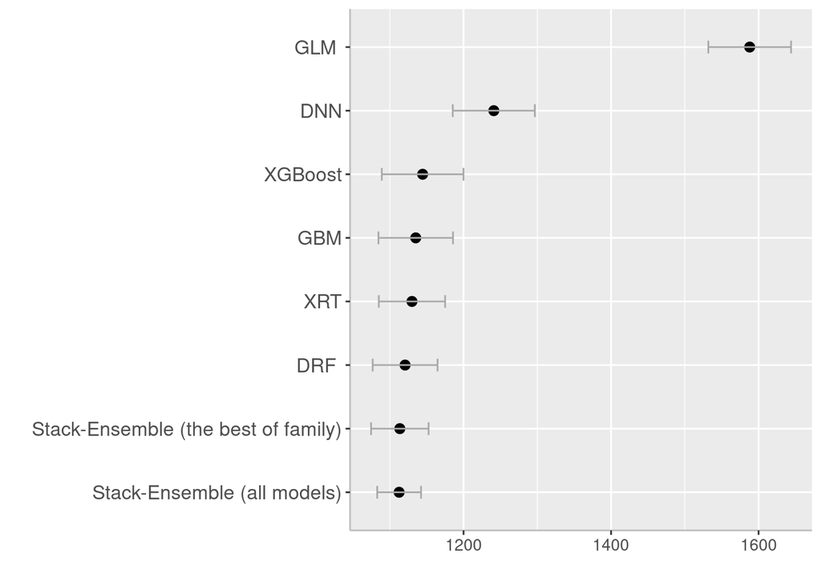

```r
print(cv.RMSE.p)
```

## MAE - CV

```r
## Create a data-frame
glm.MAE<-cv.GLM[1,c(1:2)]
drf.MAE<-cv.DRF[1,c(1:2)]
xrt.MAE<-cv.XRT[1,c(1:2)]
gbm.MAE<-cv.GBM[1,c(1:2)]
xgboost.MAE<-cv.XGBoost[1,c(1:2)]
dnn.MAE<-cv.DNN[1,c(1:2)]
stack_all.MAE<-cv.stack_all[1,c(1:2)]
stack_best.MAE<-cv.stack_best[1,c(1:2)]

cv.MAE<-rbind(glm.MAE, drf.MAE, xrt.MAE, gbm.MAE,
               xgboost.MAE, dnn.MAE, stack_all.MAE, stack_best.MAE )

rownames(cv.MAE) <- c("GLM ", "DRF ", "XRT", "GBM", "XGBoost", "DNN",
                       "Stack-Ensemble (all models)", "Stack-Ensemble (the best of family)")
cv.MAE <- tibble::rownames_to_column(cv.MAE, "Models")
cv.MAE <-arrange(cv.MAE ,desc(mean))

## Plot
tiff( file="FIGURE_CV_MAE_BORO.tif",
      width=7,   height=5,
      units = "in",
      pointsize = 10,
      res=600, bg = "white",
      compression =  "lzw")

cv.MAE.p<-ggplot(cv.MAE, aes(y=mean, x=reorder(Models, +mean))) +
  ylab('') +
  xlab('')+
  geom_point(colour = "black", size = 2.5)+
  geom_errorbar(aes(ymin=mean-sd,
                    ymax=mean+sd),
                width=.2,
                linetype=1,
                color ="dark grey") +
  #scale_y_continuous(limits=c(0.6,1), breaks=seq(0.6, 1, 0.2)) +
  theme(axis.line = element_line(colour = "grey"),
        axis.text.y=element_text(size=12),
        axis.text.x = element_text(size=10),
        axis.title.x = element_text(size=12),
        axis.title.y = element_text(size=12))+
  coord_flip()
print(cv.MAE.p)
dev.off()
```

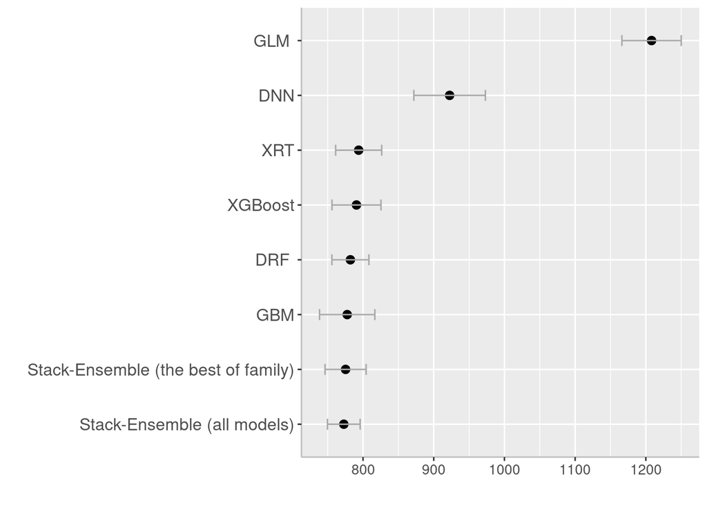

```r
print(cv.MAE.p)
```

## R2 - CV

```r
## Create a data-frame
glm.R2<-cv.GLM[5,c(1:2)]
drf.R2<-cv.DRF[4,c(1:2)]
xrt.R2<-cv.XRT[4,c(1:2)]
gbm.R2<-cv.GBM[4,c(1:2)]
xgboost.R2<-cv.XGBoost[4,c(1:2)]
dnn.R2<-cv.DNN[4,c(1:2)]
stack_all.R2<-cv.stack_all[5,c(1:2)]
stack_best.R2<-cv.stack_best[5,c(1:2)]

cv.R2<-rbind(glm.R2, drf.R2, xrt.R2, gbm.R2,
               xgboost.R2, dnn.R2, stack_all.R2, stack_best.R2 )

rownames(cv.R2) <- c("GLM ", "DRF ", "XRT", "GBM", "XGBoost", "DNN",
                       "Stack-Ensemble (all models)", "Stack-Ensemble (the best of family)")
cv.R2 <- tibble::rownames_to_column(cv.R2, "Models")
cv.R2 <-arrange(cv.R2 ,desc(mean))

## Plot
tiff( file="FIGURE_CV_R2_BORO.tif",
      width=7,   height=5,
      units = "in",
      pointsize = 10,
      res=600, bg = "white",
      compression =  "lzw")

cv.R2.p<-ggplot(cv.R2, aes(y=mean, x=reorder(Models, +mean))) +
  ylab('') +
  xlab('')+
  geom_point(colour = "black", size = 2.5)+
  geom_errorbar(aes(ymin=mean-sd,
                    ymax=mean+sd),
                width=.2,
                linetype=1,
                color ="dark grey") +
  #scale_y_continuous(limits=c(0.6,1), breaks=seq(0.6, 1, 0.2)) +
  theme(axis.line = element_line(colour = "grey"),
        axis.text.y=element_text(size=12),
        axis.text.x = element_text(size=10),
        axis.title.x = element_text(size=12),
        axis.title.y = element_text(size=12))+
  coord_flip()
print(cv.R2.p)
dev.off()
```

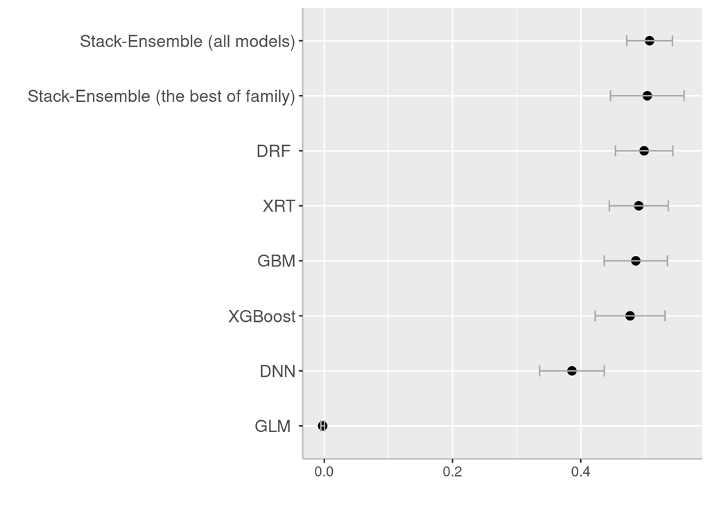

```r
print(cv.R2.p)
```

## Model Performance

### The best ML

```r
per.best.train<-h2o.performance(best_ML, h_train)
per.best.test<-h2o.performance(best_ML, h_test)
per.best.cv<-h2o.performance(best_stack, xval = TRUE)
#per.stack_best.train
per.best.test
```

```
## H2ORegressionMetrics: stackedensemble
##
## MSE:  1260391
## RMSE:  1122.671
## MAE:  786.5175
## RMSLE:  0.5412562
## Mean Residual Deviance :  1260391
```

```r
#per.stack_best.cv
```

### The best Stack-Ensemble

```r
per.stack_best.train<-h2o.performance(best_stack, h_train)
per.stack_best.test<-h2o.performance(best_stack, h_test)
per.stack_best.cv<-h2o.performance(best_stack, xval = TRUE)
#per.stack_best.train
per.stack_best.test
```

```
## H2ORegressionMetrics: stackedensemble
##
## MSE:  1260391
## RMSE:  1122.671
## MAE:  786.5175
## RMSLE:  0.5412562
## Mean Residual Deviance :  1260391
```

```r
#per.stack_best.cv
```

### The best GLM

```r
# ### Training
per.best_GLM.train<-h2o.performance(best_GLM, h_train)
per.best_GLM.test<-h2o.performance(best_GLM, h_test)
per.best_GLM.cv<-h2o.performance(best_GLM, xval = TRUE)
#per.best_GLM.train
per.best_GLM.test
```

```
## H2ORegressionMetrics: glm
##
## MSE:  2642459
## RMSE:  1625.564
## MAE:  1238.627
## RMSLE:  0.6286414
## Mean Residual Deviance :  2642459
## R^2 :  -0.0001500276
## Null Deviance :3120872797
## Null D.o.F. :1180
## Residual Deviance :3120743727
## Residual D.o.F. :1082
## AIC :21015.24
```

```r
#per.best_GLM.cv
```

### The best DRF

```r
# ### Training
per.best_DRF.train<-h2o.performance(best_DRF, h_train)
per.best_DRF.test<-h2o.performance(best_DRF, h_test)
per.best_DRF.cv<-h2o.performance(best_DRF, xval = TRUE)
#per.best_DRF.train
per.best_DRF.test
```

```
## H2ORegressionMetrics: drf
##
## MSE:  1282046
## RMSE:  1132.275
## MAE:  793.0818
## RMSLE:  0.5430859
## Mean Residual Deviance :  1282046
```

```r
#per.best_DRF.cv
```

### The best XRT

```r
# ### Training
per.best_XRT.train<-h2o.performance(best_XRT, h_train)
per.best_XRT.test<-h2o.performance(best_XRT, h_test)
per.best_XRT.cv<-h2o.performance(best_XRT, xval = TRUE)
#per.best_XRT.train
per.best_XRT.test
```

```
## H2ORegressionMetrics: drf
##
## MSE:  1293584
## RMSE:  1137.358
## MAE:  808.1761
## RMSLE:  0.5432746
## Mean Residual Deviance :  1293584
```

```r
#per.best_XRT.cv
```

### The best GBM

```r
# ### Training
per.best_GBM.train<-h2o.performance(best_GBM, h_train)
per.best_GBM.test<-h2o.performance(best_GBM, h_test)
per.best_GBM.cv<-h2o.performance(best_GBM, xval = TRUE)
#per.best_GBM.train
per.best_GBM.test
```

```
## H2ORegressionMetrics: gbm
##
## MSE:  1315593
## RMSE:  1146.993
## MAE:  803.5554
## RMSLE:  0.5419153
## Mean Residual Deviance :  1315593
```

```r
#per.best_GBM.cv
```

### The best XGBoost

```r
# ### Training
per.best_XGBoost.train<-h2o.performance(best_XGBoost, h_train)
per.best_XGBoost.test<-h2o.performance(best_XGBoost, h_test)
per.best_XGBoost.cv<-h2o.performance(best_XGBoost, xval = TRUE)
#per.best_XGBoost.train
per.best_XGBoost.test
```

```
## H2ORegressionMetrics: xgboost
##
## MSE:  1378598
## RMSE:  1174.137
## MAE:  838.0487
## RMSLE:  0.5479651
## Mean Residual Deviance :  1378598
```

```r
#per.best_XGBoost.cv
```

### The best DNN

```r
# ### Training
per.best_DNN.train<-h2o.performance(best_DNN, h_train)
per.best_DNN.test<-h2o.performance(best_DNN, h_test)
per.best_DNN.cv<-h2o.performance(best_DNN, xval = TRUE)
#per.best_DNN.train
per.best_DNN.test
```

```
## H2ORegressionMetrics: deeplearning
##
## MSE:  1404449
## RMSE:  1185.094
## MAE:  865.3236
## RMSLE:  0.5485562
## Mean Residual Deviance :  1404449
```

```r
#per.best_DNN.cv
```

## Model Comparison - Training/CV/Test

## RMSE

```r
d_rmse <- data.frame(Models = c("GLM ",
                                   "DRF ",
                                   "XRT",
                                   "GBM",
                                   "XGBoost",
                                   "DNN",
                                   "Stack-Ensemble",
                                   "Best-ML"
),
stringsAsFactors = FALSE)

d_rmse$Training <- NA
d_rmse$CV <- NA
d_rmse$Test <- NA

## Training
d_rmse[1, ]$Training<-h2o.rmse(h2o.performance(best_GLM, newdata = h_train))
d_rmse[2, ]$Training<-h2o.rmse(h2o.performance(best_DRF, newdata = h_train))
d_rmse[3, ]$Training<-h2o.rmse(h2o.performance(best_XRT, newdata = h_train))
d_rmse[4, ]$Training<-h2o.rmse(h2o.performance(best_GBM, newdata = h_train))
d_rmse[5, ]$Training<-h2o.rmse(h2o.performance(best_XGBoost, newdata = h_train))
d_rmse[6, ]$Training<-h2o.rmse(h2o.performance(best_DNN, newdata = h_train))
d_rmse[7, ]$Training<-h2o.rmse(h2o.performance(best_stack, newdata = h_train))
d_rmse[8, ]$Training<-h2o.rmse(h2o.performance(best_ML, newdata = h_train))

## Cross_Validation
d_rmse[1, ]$CV<-h2o.rmse(h2o.performance(best_GLM, xval = TRUE))
d_rmse[2, ]$CV<-h2o.rmse(h2o.performance(best_DRF, xval = TRUE))
d_rmse[3, ]$CV<-h2o.rmse(h2o.performance(best_XRT, xval = TRUE))
d_rmse[4, ]$CV<-h2o.rmse(h2o.performance(best_GBM, xval = TRUE))
d_rmse[5, ]$CV<-h2o.rmse(h2o.performance(best_XGBoost, xval = TRUE))
d_rmse[6, ]$CV<-h2o.rmse(h2o.performance(best_DNN, xval = TRUE))
d_rmse[7, ]$CV<-h2o.rmse(h2o.performance(best_stack, xval = TRUE))
d_rmse[8, ]$CV<-h2o.rmse(h2o.performance(best_ML, xval = TRUE))

##  Test data
d_rmse[1, ]$Test<-h2o.rmse(h2o.performance(best_GLM, newdata = h_test))
d_rmse[2, ]$Test<-h2o.rmse(h2o.performance(best_DRF, newdata = h_test))
d_rmse[3, ]$Test<-h2o.rmse(h2o.performance(best_XRT, newdata = h_test))
d_rmse[4, ]$Test<-h2o.rmse(h2o.performance(best_GBM, newdata = h_test))
d_rmse[5, ]$Test<-h2o.rmse(h2o.performance(best_XGBoost, newdata = h_test))
d_rmse[6, ]$Test<-h2o.rmse(h2o.performance(best_DNN, newdata = h_test))
d_rmse[7, ]$Test<-h2o.rmse(h2o.performance(best_stack, newdata = h_test))
d_rmse[8, ]$Test<-h2o.rmse(h2o.performance(best_ML, newdata = h_test))

write.csv(d_rmse, "rmse_all_models.csv", row.names = F)
# Show Comparison (rmse: Lower = Better)
datatable(d_rmse, rownames = FALSE, options = list(pageLength = 10, scrollX = TRUE, round)) %>%
  formatRound(columns = -1, digits = 3)
```

| Models | Training | CV | Test |
| --- | --- | --- | --- |
| GLM | 1588.4657363392 | 1588.85895585979 | 1625.5641181138 |
| DRF | 575.583390263191 | 1121.21702984586 | 1132.27483823244 |
| XRT | 619.232288194691 | 1130.34729645938 | 1137.3582298251 |
| GBM | 386.655534446536 | 1131.39239624212 | 1146.99285752952 |
| XGBoost | 481.145382941575 | 1145.73388526306 | 1174.13706051668 |
| DNN | 994.951258807392 | 1232.22551434304 | 1185.09433299826 |
| Stack-Ensemble | 495.382155644545 | 1112.41162078185 | 1122.67137251182 |
| Best-ML | 495.382155644545 | 1112.41162078185 | 1122.67137251182 |

## MAE

```r
d_mae <- data.frame(Models = c("GLM ",
                                   "DRF ",
                                   "XRT",
                                   "GBM",
                                   "XGBoost",
                                   "DNN",
                                   "Stack-Ensemble",
                                   "Best-ML"
),
stringsAsFactors = FALSE)

d_mae$Training <- NA
d_mae$CV <- NA
d_mae$Test <- NA

## Training
d_mae[1, ]$Training<-h2o.mae(h2o.performance(best_GLM, newdata = h_train))
d_mae[2, ]$Training<-h2o.mae(h2o.performance(best_DRF, newdata = h_train))
d_mae[3, ]$Training<-h2o.mae(h2o.performance(best_XRT, newdata = h_train))
d_mae[4, ]$Training<-h2o.mae(h2o.performance(best_GBM, newdata = h_train))
d_mae[5, ]$Training<-h2o.mae(h2o.performance(best_XGBoost, newdata = h_train))
d_mae[6, ]$Training<-h2o.mae(h2o.performance(best_DNN, newdata = h_train))
d_mae[7, ]$Training<-h2o.mae(h2o.performance(best_stack, newdata = h_train))
d_mae[8, ]$Training<-h2o.mae(h2o.performance(best_ML, newdata = h_train))

## Cross_Validation
d_mae[1, ]$CV<-h2o.mae(h2o.performance(best_GLM, xval = TRUE))
d_mae[2, ]$CV<-h2o.mae(h2o.performance(best_DRF, xval = TRUE))
d_mae[3, ]$CV<-h2o.mae(h2o.performance(best_XRT, xval = TRUE))
d_mae[4, ]$CV<-h2o.mae(h2o.performance(best_GBM, xval = TRUE))
d_mae[5, ]$CV<-h2o.mae(h2o.performance(best_XGBoost, xval = TRUE))
d_mae[6, ]$CV<-h2o.mae(h2o.performance(best_DNN, xval = TRUE))
d_mae[7, ]$CV<-h2o.mae(h2o.performance(best_stack, xval = TRUE))
d_mae[8, ]$CV<-h2o.mae(h2o.performance(best_ML, xval = TRUE))

##  Test data
d_mae[1, ]$Test<-h2o.mae(h2o.performance(best_GLM, newdata = h_test))
d_mae[2, ]$Test<-h2o.mae(h2o.performance(best_DRF, newdata = h_test))
d_mae[3, ]$Test<-h2o.mae(h2o.performance(best_XRT, newdata = h_test))
d_mae[4, ]$Test<-h2o.mae(h2o.performance(best_GBM, newdata = h_test))
d_mae[5, ]$Test<-h2o.mae(h2o.performance(best_XGBoost, newdata = h_test))
d_mae[6, ]$Test<-h2o.mae(h2o.performance(best_DNN, newdata = h_test))
d_mae[7, ]$Test<-h2o.mae(h2o.performance(best_stack, newdata = h_test))
d_mae[8, ]$Test<-h2o.mae(h2o.performance(best_ML, newdata = h_test))

write.csv(d_mae, "mae_all_models.csv", row.names = F)
# Show Comparison (mae: Lower = Better)
datatable(d_mae, rownames = FALSE, options = list(pageLength = 10, scrollX = TRUE, round)) %>%
  formatRound(columns = -1, digits = 3)
```

| Models | Training | CV | Test |
| --- | --- | --- | --- |
| GLM | 1207.71740816982 | 1208.11552690947 | 1238.62736238006 |
| DRF | 406.2836170469 | 781.98709448828 | 793.081836890188 |
| XRT | 441.491542759298 | 793.761854848635 | 808.176084165303 |
| GBM | 261.664098331317 | 779.267750566925 | 803.555416673634 |
| XGBoost | 303.367412008046 | 790.727753787241 | 838.048725693434 |
| DNN | 720.932686629357 | 915.759365381844 | 865.32362839716 |
| Stack-Ensemble | 351.135256159522 | 772.558862819062 | 786.517542486805 |
| Best-ML | 351.135256159522 | 772.558862819062 | 786.517542486805 |

## R2

```r
d_r2 <- data.frame(Models = c("GLM ",
                                   "DRF ",
                                   "XRT",
                                   "GBM",
                                   "XGBoost",
                                   "DNN",
                                   "Stack-Ensemble",
                                   "Best-ML"
),
stringsAsFactors = FALSE)

d_r2$Training <- NA
d_r2$CV <- NA
d_r2$Test <- NA

## Training

d_r2[1, ]$Training<-h2o.r2(h2o.performance(best_GLM, newdata = h_train))
d_r2[2, ]$Training<-h2o.r2(h2o.performance(best_DRF, newdata = h_train))
d_r2[3, ]$Training<-h2o.r2(h2o.performance(best_XRT, newdata = h_train))
d_r2[4, ]$Training<-h2o.r2(h2o.performance(best_GBM, newdata = h_train))
d_r2[5, ]$Training<-h2o.r2(h2o.performance(best_XGBoost, newdata = h_train))
d_r2[6, ]$Training<-h2o.r2(h2o.performance(best_DNN, newdata = h_train))
d_r2[7, ]$Training<-h2o.r2(h2o.performance(best_stack, newdata = h_train))
d_r2[8, ]$Training<-h2o.r2(h2o.performance(best_ML, newdata = h_train))

## Cross_Validation

d_r2[1, ]$CV<-h2o.r2(h2o.performance(best_GLM, xval = TRUE))
d_r2[2, ]$CV<-h2o.r2(h2o.performance(best_DRF, xval = TRUE))
d_r2[3, ]$CV<-h2o.r2(h2o.performance(best_XRT, xval = TRUE))
d_r2[4, ]$CV<-h2o.r2(h2o.performance(best_GBM, xval = TRUE))
d_r2[5, ]$CV<-h2o.r2(h2o.performance(best_XGBoost, xval = TRUE))
d_r2[6, ]$CV<-h2o.r2(h2o.performance(best_DNN, xval = TRUE))
d_r2[7, ]$CV<-h2o.r2(h2o.performance(best_stack, xval = TRUE))
d_r2[8, ]$CV<-h2o.r2(h2o.performance(best_ML, xval = TRUE))

##  Test data

d_r2[1, ]$Test<-h2o.r2(h2o.performance(best_GLM, newdata = h_test))
d_r2[2, ]$Test<-h2o.r2(h2o.performance(best_DRF, newdata = h_test))
d_r2[3, ]$Test<-h2o.r2(h2o.performance(best_XRT, newdata = h_test))
d_r2[4, ]$Test<-h2o.r2(h2o.performance(best_GBM, newdata = h_test))
d_r2[5, ]$Test<-h2o.r2(h2o.performance(best_XGBoost, newdata = h_test))
d_r2[6, ]$Test<-h2o.r2(h2o.performance(best_DNN, newdata = h_test))
d_r2[7, ]$Test<-h2o.r2(h2o.performance(best_stack, newdata = h_test))
d_r2[8, ]$Test<-h2o.r2(h2o.performance(best_ML, newdata = h_test))

write.csv(d_r2, "r2_all_models.csv", row.names = F)
# Show Comparison (r2: Lower = Better)
datatable(d_r2, rownames = FALSE, options = list(pageLength = 10, scrollX = TRUE, round)) %>%
  formatRound(columns = -1, digits = 3)
```

| Models | Training | CV | Test |
| --- | --- | --- | --- |
| GLM | 5.21061478819806e-05 | -0.000443022818400474 | -0.000150027569251421 |
| DRF | 0.868708027531867 | 0.501803080072741 | 0.514755462188614 |
| XRT | 0.848040150787993 | 0.493656234467588 | 0.510388633454249 |
| GBM | 0.940752486448939 | 0.49271948804233 | 0.502058446801574 |
| XGBoost | 0.908256709525757 | 0.479777439402054 | 0.478211461368948 |
| DNN | 0.607693703291048 | 0.398269450111553 | 0.468427157255066 |
| Stack-Ensemble | 0.902747139418433 | 0.509597470841433 | 0.522951823975215 |
| Best-ML | 0.902747139418433 | 0.509597470841433 | 0.522951823975215 |

## Create a data-frame Model Perforamnce for the test data

```r
test.matrix <- data.frame(Models = c("GLM ",
                                        "DRF ",
                                        "XRT",
                                        "GBM",
                                        "XGBoost",
                                        "DNN",
                                        "Stack-Ensemble",
                                        "Best-ML"
                                        ),
                                        stringsAsFactors = FALSE)

test.matrix$MAE<-round((d_mae$Test),3)
test.matrix$RMSE<-round((d_rmse$Test),3)
test.matrix$R2<-round((d_r2$Test),3)

write.csv(test.matrix, "test_matrix_all_models.csv", row.names = F)
# Show Comparison (F1: high = Better)
datatable(test.matrix, rownames = FALSE, options = list(pageLength = 10, scrollX = TRUE, round)) %>%
  formatRound(columns = -1, digits = 3)
```

| Models | MAE | RMSE | R2 |
| --- | --- | --- | --- |
| GLM | 1238.627 | 1625.564 | 0 |
| DRF | 793.082 | 1132.275 | 0.515 |
| XRT | 808.176 | 1137.358 | 0.51 |
| GBM | 803.555 | 1146.993 | 0.502 |
| XGBoost | 838.049 | 1174.137 | 0.478 |
| DNN | 865.324 | 1185.094 | 0.468 |
| Stack-Ensemble | 786.518 | 1122.671 | 0.523 |
| Best-ML | 786.518 | 1122.671 | 0.523 |

```r
#best_ML<- h2o.loadModel("StackedEnsemble_AllModels_3_AutoML_1_20211102_184016")
```

### 1: 1 Plot Ovserved vs Predicted Yields

```r
bestML.test<-as.data.frame(h2o.predict(object = best_ML, newdata = h_test))
test.xy<-test.mf[,c(1:5,17)]
test.xy$Predicted<-bestML.test$predict
write.csv(test.xy, "test_pred.csv", row.names = F)
```

```r
tiff( file="FIGURE_Obs_Pred_boro_Yield.tif",
width=5.5, height=5, units="in", res=600)

pred.yield.test<-ggplot(data=test.xy, aes(x=YIELD, y=Predicted))+
  geom_point(size = 1.0,colour = "grey")+
  geom_smooth(method = "lm", se = FALSE, colour="black",size=0.5)+
  scale_x_continuous(limits=c(0,10000), breaks=seq(0, 10000, 2000))+
  scale_y_continuous(limits=c(0,10000), breaks=seq(0, 10000, 2000)) +
  theme_light() +
  theme(
    panel.background = element_rect(fill = "white",colour = "gray75",size = 0.5, linetype = "solid"),
    axis.line = element_line(colour = "grey"),
    panel.grid.major = element_blank(),
    axis.title.x=element_blank(),
    axis.title.y=element_blank(),
    axis.text.x=element_text(size=14, colour="black"),
    axis.text.y=element_text(size=14,angle = 90,vjust = 0.5, hjust=0.5, colour='black'))+
  geom_abline(slope=1, intercept=0,linetype="dashed",size=0.5)
print(pred.yield.test)
dev.off()
```

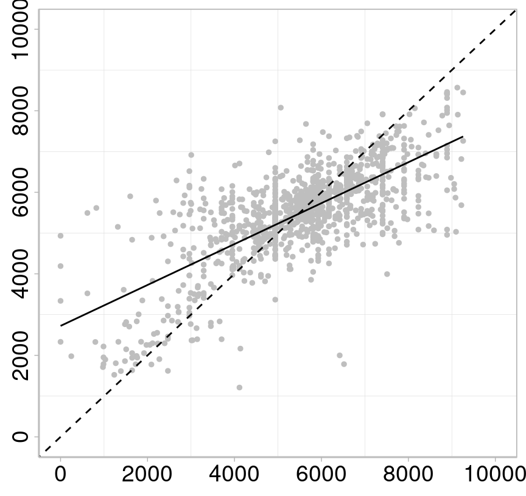

```r
print(pred.yield.test)
```

# Interpretable Machine Learning

The following code extracts these items for the h2o example:

## Create Model Explainer for Best_ML

```r
pred_fun_best_ML <- function(object, newdata)  {
  results <- as.vector(h2o.predict(object, as.h2o(newdata)))
  return(results)
}
```

### Explainer For Training Data

```r
explainer_train <- DALEX::explain(
  model = best_ML,
  type="regression",
  data = x_train,
  y = y_train,
  predict_function = pred_fun_best_ML,
  label = "The Best ML- Training"
)
```

## Permutation-based feature importance

```r
vip_train <- variable_importance(explainer_train, type="difference")
datatable(as.data.frame(vip_train),
          rownames = FALSE, options = list(pageLength = 10, scrollX = TRUE, round)) %>%
  formatRound(columns = -1, digits = 4)
```

```r
tiff( file="FIGURE_VIP.tif",
      width=6, height=18, units="in", res=600)
p.vip_train<-plot(vip_train)
print(p.vip_train)
dev.off()
```

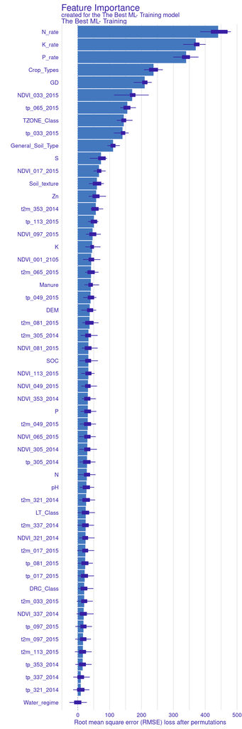

```r
print(p.vip_train)
```

### Create VIP table

```r
vip_train_stat<-vip_train %>%
  group_by(variable) %>%
  summarise(mean.loss = mean(dropout_loss, na.rm = TRUE),
            sd.loss = sd(dropout_loss, na.rm = TRUE),
            n.loss = n()) %>%
  mutate(se.loss = sd.loss / sqrt(n.loss),
         lower.ci.loss = mean.loss - qt(1 - (0.05 / 2), n.loss - 1) * se.loss,
         upper.ci.loss = mean.loss + qt(1 - (0.05 / 2), n.loss - 1) * se.loss)

vip_train_stat<-filter(vip_train_stat,  variable != "_baseline_")
vip_train_stat<-filter(vip_train_stat,  variable != "_full_model_")

vip_train_stat$Scale_VIP<-(vip_train_stat$mean.loss - min(vip_train_stat$mean.loss))/
                         (max(vip_train_stat$mean.loss)-min(vip_train_stat$mean.loss))

datatable(as.data.frame(vip_train_stat),
          rownames = FALSE, options = list(pageLength = 10, scrollX = TRUE, round)) %>%
  formatRound(columns = -1, digits = 4)
write.csv(vip_train_stat, "vip_stat_train.csv", row.names = F)
```

# Partial-dependence Profiles

```r
vip_stat_df<-vip_train_stat %>%
   arrange(desc(mean.loss))

var.names.stack=vip_stat_df[1]
var_1st=var.names.stack[1,]$variable
var_1st
```

```
## [1] "N_rate"
```

```r
var_2nd=var.names.stack[2,]$variable
var_2nd
```

```
## [1] "K_rate"
```

```r
var_3rd=var.names.stack[3,]$variable
var_3rd
```

```
## [1] "P_rate"
```

```r
var_4th=var.names.stack[4,]$variable
var_4th
```

```
## [1] "Crop_Types"
```

### PDP Plot of of 1st Important variable

```r
pdp_1st <- variable_effect(explainer_train,
                                      variable =  var_1st,
                                      type = "partial_dependency")
write.csv(pdp_1st , "PDP_1st.csv", row.names = F)
```

```r
tiff( file="FIGURE_PDP_1st.tif",
width=5, height=5, units="in", res=600)
pdp_1st.p<-plot(pdp_1st)
print(pdp_1st.p)
dev.off()
```

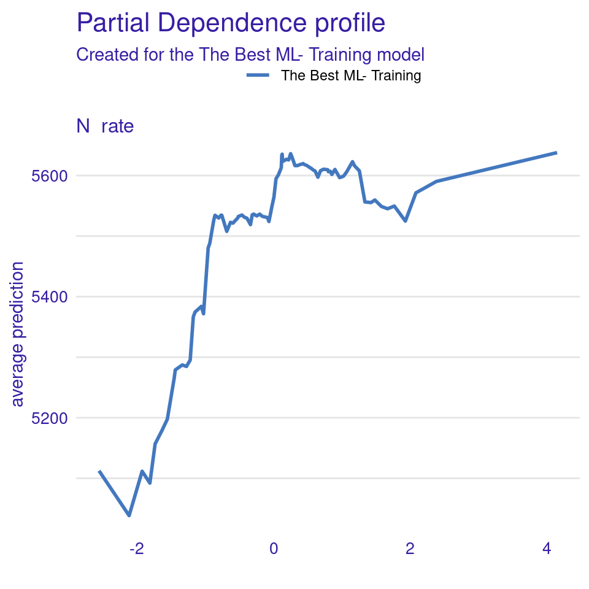

```r
print(pdp_1st.p)
```

### PDP Plot of of 2nd Important variable

```r
pdp_2nd <- variable_effect(explainer_train,
                                      variable =  var_2nd,
                                      type = "partial_dependency")
write.csv(pdp_2nd , "PDP_2nd.csv", row.names = F)
```

```r
tiff( file="FIGURE_PDP_2nd.tif",
width=5, height=5, units="in", res=600)
pdp_2nd.p<-plot(pdp_2nd)
print(pdp_2nd.p)
dev.off()
```

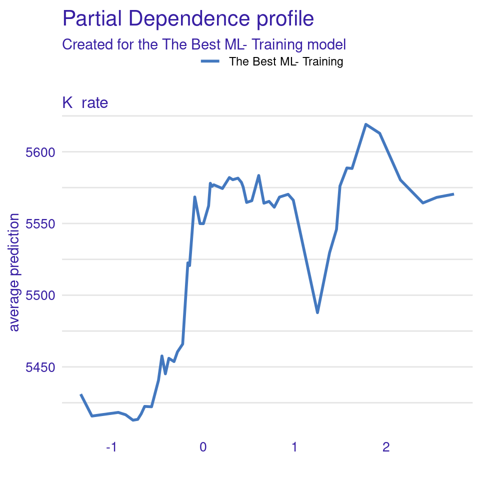

```r
print(pdp_2nd.p)
```

### PDP Plot of of 3rd Important variable

```r
pdp_3rd <- variable_effect(explainer_train,
                                      variable =  var_3rd,
                                      type = "partial_dependency")
write.csv(pdp_3rd , "PDP_3rd.csv", row.names = F)
```

```r
tiff( file="FIGURE_PDP_3rd_Aman.tif",
width=5, height=5, units="in", res=600)
pdp_3rd.p<-plot(pdp_3rd)
print(pdp_3rd.p)
dev.off()
```

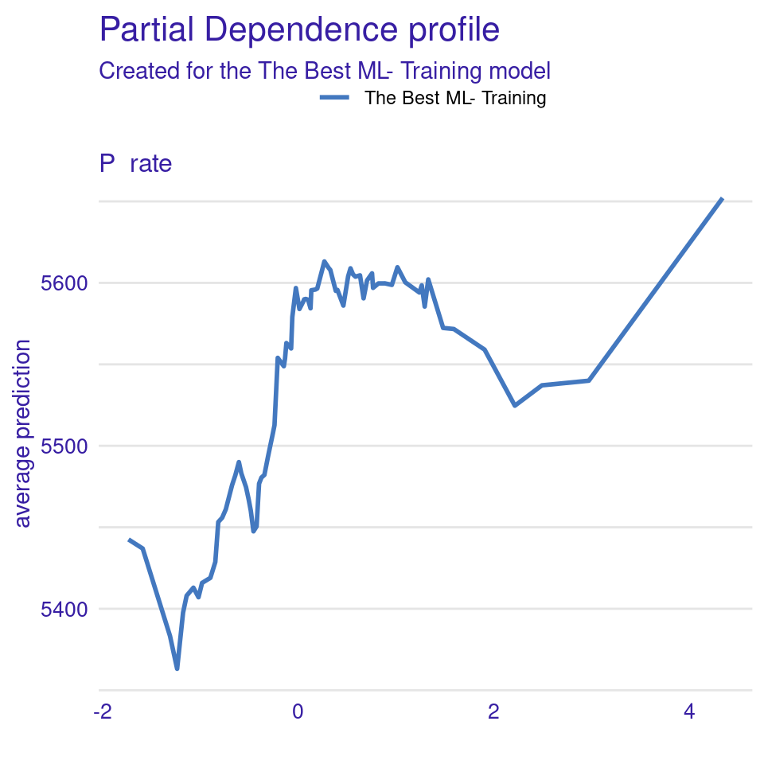

```r
print(pdp_3rd.p)
```

### PDP Plot of of 4th Important variable

```r
pdp_4th <- variable_effect(explainer_train,
                                      variable =  var_4th,
                                      type = "partial_dependency")
write.csv(pdp_4th , "PDP_4th.csv", row.names = F)
```

```r
tiff( file="FIGURE_PDP_4th.tif",
width=5, height=5, units="in", res=600)
pdp_4th.p<-plot(pdp_4th)
print(pdp_4th.p)
dev.off()
```

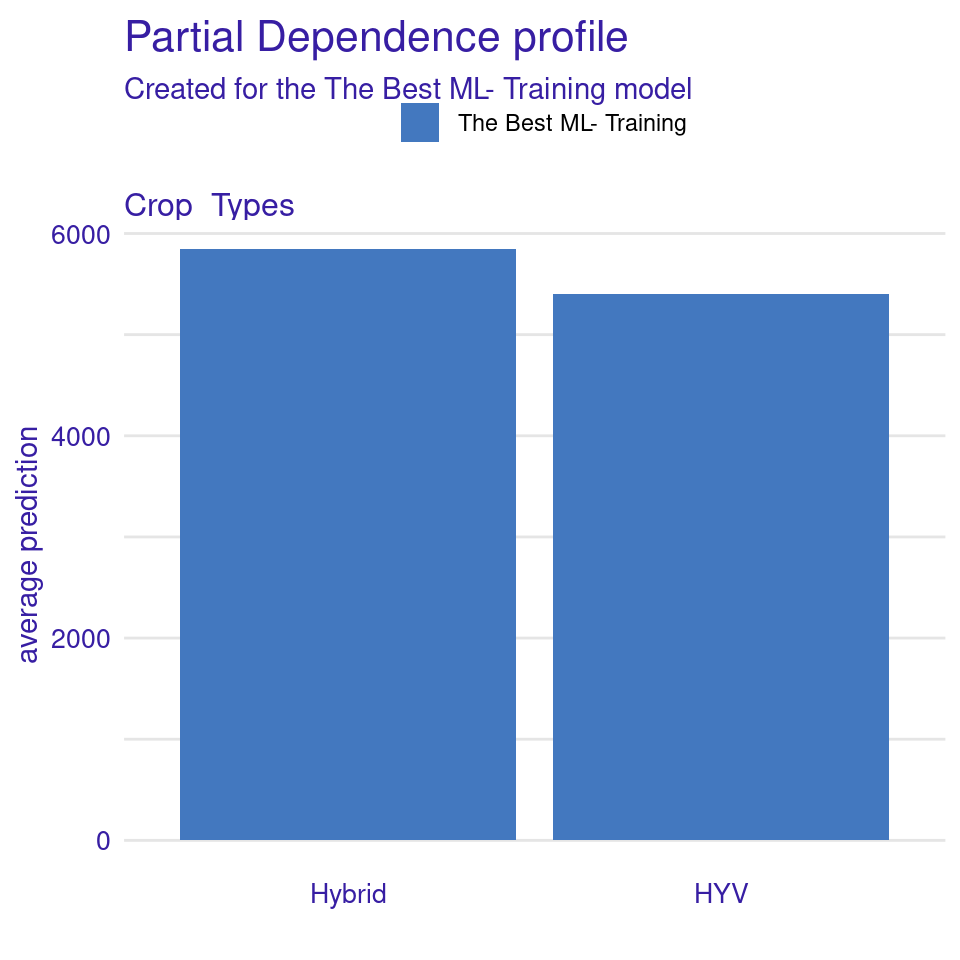

```r
print(pdp_4th.p)
```

## Partial, Accumulated and Local-dependence profils

```r
## !st important
pd_stack_1st <- model_profile(explainer = explainer_train, type = "partial", variables = var_1st)
ld_stack_1st <- model_profile(explainer = explainer_train, type = "conditional", variables = var_1st)
al_stack_1st <- model_profile(explainer = explainer_train, type = "accumulated", variables = var_1st)

write.csv(pd_stack_1st$agr_profiles, "partial_dependence_1st.csv")
write.csv(ld_stack_1st$agr_profiles, "local_dependence_1st.csv")
write.csv(al_stack_1st$agr_profiles, "accumulate_local_1st.csv")

# 2nd Important
pd_stack_2nd <- model_profile(explainer = explainer_train, type = "partial", variables = var_2nd)
ld_stack_2nd <- model_profile(explainer = explainer_train, type = "conditional", variables = var_2nd)
al_stack_2nd <- model_profile(explainer = explainer_train, type = "accumulated", variables = var_2nd)

write.csv(pd_stack_2nd$agr_profiles, "partial_dependence_2nd.csv")
write.csv(ld_stack_2nd$agr_profiles, "local_dependence_2nd.csv")
write.csv(al_stack_2nd$agr_profiles, "accumulated_local_2nd.csv")

# 3rd Important
pd_stack_3rd <- model_profile(explainer = explainer_train, type = "partial", variables = var_3rd)
ld_stack_3rd <- model_profile(explainer = explainer_train, type = "conditional", variables = var_3rd)
al_stack_3rd <- model_profile(explainer = explainer_train, type = "accumulated", variables = var_3rd)

write.csv(pd_stack_3rd$agr_profiles, "partial_dependence_3rd.csv")
write.csv(ld_stack_3rd$agr_profiles, "local_dependence_3rd.csv")
write.csv(al_stack_3rd$agr_profiles, "accumulated_local_3rd.csv")

# 4th Important
pd_stack_4th <- model_profile(explainer = explainer_train, type = "partial", variables = var_4th)
ld_stack_4th <- model_profile(explainer = explainer_train, type = "conditional", variables = var_4th)
al_stack_4th <- model_profile(explainer = explainer_train, type = "accumulated", variables = var_4th)

write.csv(pd_stack_4th$agr_profiles, "partial_dependence_4th.csv")
write.csv(ld_stack_4th$agr_profiles, "local_dependence_4th.csv")
write.csv(al_stack_4th$agr_profiles, "accumulated_local_4th.csv")
```

## Feature interactions

```r
# create predictor object to pass to explainer functions
mod <- Predictor$new(best_ML, data =x_train)
inter<-Interaction$new(mod)
```

[output not shown]

[output not shown]

[output not shown]

[output not shown]

[output not shown]

[output not shown]

[output not shown]

[output not shown]

[output not shown]

[output not shown]

[output not shown]

[output not shown]

[output not shown]

[output not shown]

[output not shown]

[output not shown]

[output not shown]

```r
tiff( file="FIGURE_Interaction.tif",
width=6, height=18, units="in", res=600)
p.inter<-plot(inter)
print(p.inter)
dev.off()
```

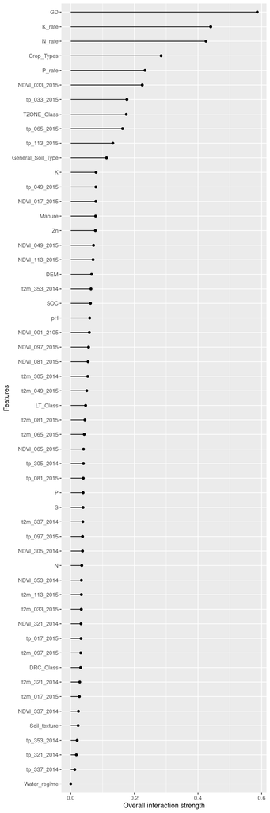

```r
print(p.inter)
```

```r
dat<-inter$results
write.csv(dat, "Feature_Interaction.csv", row.names=F)
```